# 红酒成分与红酒质量关系分析

# 单变量分析

### 你的数据集结构是什么？

```
## 'data.frame':    1599 obs. of  13 variables:
##  $ X                   : int  1 2 3 4 5 6 7 8 9 10 ...
##  $ fixed.acidity       : num  7.4 7.8 7.8 11.2 7.4 7.4 7.9 7.3 7.8 7.5 ...
##  $ volatile.acidity    : num  0.7 0.88 0.76 0.28 0.7 0.66 0.6 0.65 0.58 0.5 ...
##  $ citric.acid         : num  0 0 0.04 0.56 0 0 0.06 0 0.02 0.36 ...
##  $ residual.sugar      : num  1.9 2.6 2.3 1.9 1.9 1.8 1.6 1.2 2 6.1 ...
##  $ chlorides           : num  0.076 0.098 0.092 0.075 0.076 0.075 0.069 0.065 0.073 0.071 ...
##  $ free.sulfur.dioxide : num  11 25 15 17 11 13 15 15 9 17 ...
##  $ total.sulfur.dioxide: num  34 67 54 60 34 40 59 21 18 102 ...
##  $ density             : num  0.998 0.997 0.997 0.998 0.998 ...
##  $ pH                  : num  3.51 3.2 3.26 3.16 3.51 3.51 3.3 3.39 3.36 3.35 ...
##  $ sulphates           : num  0.56 0.68 0.65 0.58 0.56 0.56 0.46 0.47 0.57 0.8 ...
##  $ alcohol             : num  9.4 9.8 9.8 9.8 9.4 9.4 9.4 10 9.5 10.5 ...
##  $ quality             : int  5 5 5 6 5 5 5 7 7 5 ...
```

#### 数据变量解释

我们的数据集由13个变量组成，具有1599个观测值 0 - X (index) 1 - fixed acidity (酒石酸 - g / dm^3) 2 - volatile acidity (乙酸 acid - g / dm^3) 3 - citric acid (柠檬酸 g / dm^3) 4 - residual sugar (残糖 g / dm^3) 5 - chlorides (氯化钠 - g / dm^3 6 - free sulfur dioxide (游离二氧化硫 mg / dm^3) 7 - total sulfur dioxide ( 总二氧化硫 mg / dm^3) 8 - density ( 密度 g / cm^3) 9 - pH 10 - sulphates (硫酸钾 - g / dm3) 11 - alcohol (酒精 % by volume) Output variable (based on sensory data): 输出变量（基于感官数据）： 12 - quality（得分在0到10之间）

```
##        X          fixed.acidity   volatile.acidity  citric.acid
##  Min.   :   1.0   Min.   : 4.60   Min.   :0.1200   Min.   :0.000
##  1st Qu.: 400.5   1st Qu.: 7.10   1st Qu.:0.3900   1st Qu.:0.090
##  Median : 800.0   Median : 7.90   Median :0.5200   Median :0.260
##  Mean   : 800.0   Mean   : 8.32   Mean   :0.5278   Mean   :0.271
##  3rd Qu.:1199.5   3rd Qu.: 9.20   3rd Qu.:0.6400   3rd Qu.:0.420
##  Max.   :1599.0   Max.   :15.90   Max.   :1.5800   Max.   :1.000
##  residual.sugar     chlorides       free.sulfur.dioxide
##  Min.   : 0.900   Min.   :0.01200   Min.   : 1.00
##  1st Qu.: 1.900   1st Qu.:0.07000   1st Qu.: 7.00
##  Median : 2.200   Median :0.07900   Median :14.00
##  Mean   : 2.539   Mean   :0.08747   Mean   :15.87
##  3rd Qu.: 2.600   3rd Qu.:0.09000   3rd Qu.:21.00
##  Max.   :15.500   Max.   :0.61100   Max.   :72.00
##  total.sulfur.dioxide    density             pH          sulphates
##  Min.   :  6.00       Min.   :0.9901   Min.   :2.740   Min.   :0.3300
##  1st Qu.: 22.00       1st Qu.:0.9956   1st Qu.:3.210   1st Qu.:0.5500
##  Median : 38.00       Median :0.9968   Median :3.310   Median :0.6200
##  Mean   : 46.47       Mean   :0.9967   Mean   :3.311   Mean   :0.6581
##  3rd Qu.: 62.00       3rd Qu.:0.9978   3rd Qu.:3.400   3rd Qu.:0.7300
##  Max.   :289.00       Max.   :1.0037   Max.   :4.010   Max.   :2.0000
##     alcohol         quality
##  Min.   : 8.40   Min.   :3.000
##  1st Qu.: 9.50   1st Qu.:5.000
##  Median :10.20   Median :6.000
##  Mean   :10.42   Mean   :5.636
##  3rd Qu.:11.10   3rd Qu.:6.000
##  Max.   :14.90   Max.   :8.000
```

### 你的数据集内感兴趣的主要特性有哪些？

我主要关注的是红酒的最终质量与哪些化学成分有关。

### 你认为数据集内哪些其他特征可以帮助你探索兴趣特点？

我认为红酒中的酒精含量，含糖量，酸度会与红酒的品质有关。

### 根据数据集内已有变量，你是否创建了任何新变量？

我可以构造一个变量，来描述红酒中没有游离的二氧化硫 Solidify sulfur dioxide= total sulfur dioxide -free sulfur dioxide total sulfur dioxide

### 在已经探究的特性中，是否存在任何异常分布？你是否对数据进行一些操作，如清洁、调整或改变数据的形式？如果是，你为什么会这样做？

# 双变量绘图选择

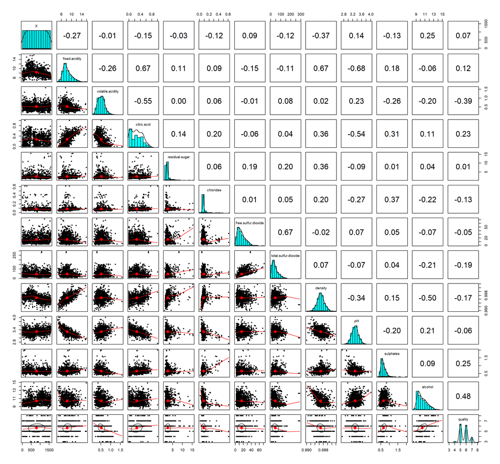

从上图可以清晰地观察出各个变量间的相关性。我们先对我们目标变量红酒质量quality来看， quality与alochol存在较强的的正相关性，相关系数为0.48； quality与sulphates存在较弱的正相关关系，仅为0.25； qulity与citric acid存在较弱的正相关关系，仅为0.23； quality与volatile acidity存在较弱的负相关关系，仅为0.39；

fixed acidity 与 citric acid存在正相关关系，达到0.67。 fixed acidity 和densitt呈现正相关关系，达到0.67。 fixed acidity与PH呈现反相关关系，达到0.68。 volatile acidity 和critric acid呈现反相关关系，达到0.55。其他变量间呈现的是弱相关关系。

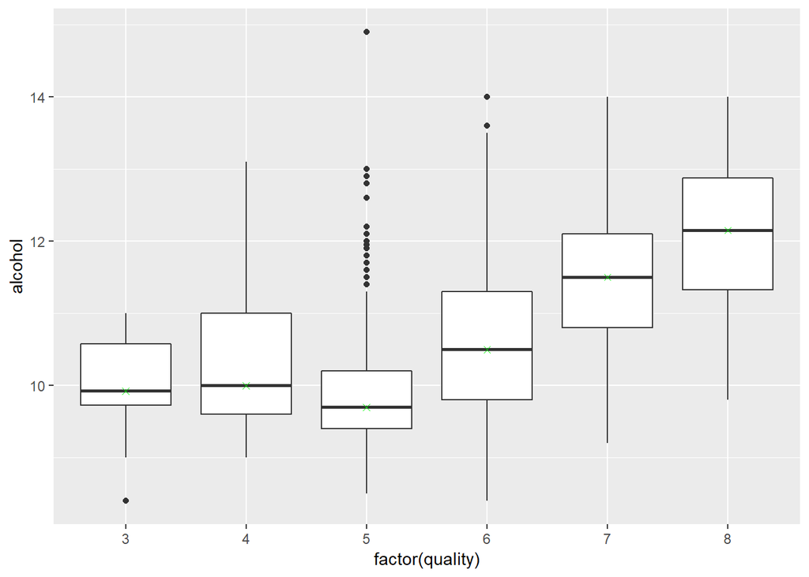

```
## wine_quality_reds$quality: 3
##    Min. 1st Qu.  Median    Mean 3rd Qu.    Max.
##   8.400   9.725   9.925   9.955  10.575  11.000
## --------------------------------------------------------
## wine_quality_reds$quality: 4
##    Min. 1st Qu.  Median    Mean 3rd Qu.    Max.
##    9.00    9.60   10.00   10.27   11.00   13.10
## --------------------------------------------------------
## wine_quality_reds$quality: 5
##    Min. 1st Qu.  Median    Mean 3rd Qu.    Max.
##     8.5     9.4     9.7     9.9    10.2    14.9
## --------------------------------------------------------
## wine_quality_reds$quality: 6
##    Min. 1st Qu.  Median    Mean 3rd Qu.    Max.
##    8.40    9.80   10.50   10.63   11.30   14.00
## --------------------------------------------------------
## wine_quality_reds$quality: 7
##    Min. 1st Qu.  Median    Mean 3rd Qu.    Max.
##    9.20   10.80   11.50   11.47   12.10   14.00
## --------------------------------------------------------
## wine_quality_reds$quality: 8
##    Min. 1st Qu.  Median    Mean 3rd Qu.    Max.
##    9.80   11.32   12.15   12.09   12.88   14.00
```

从图来看，由于quality值为3，4还有8的数量很少，因此总体上alcohol的值越大，quality值越大，两者呈正相关。

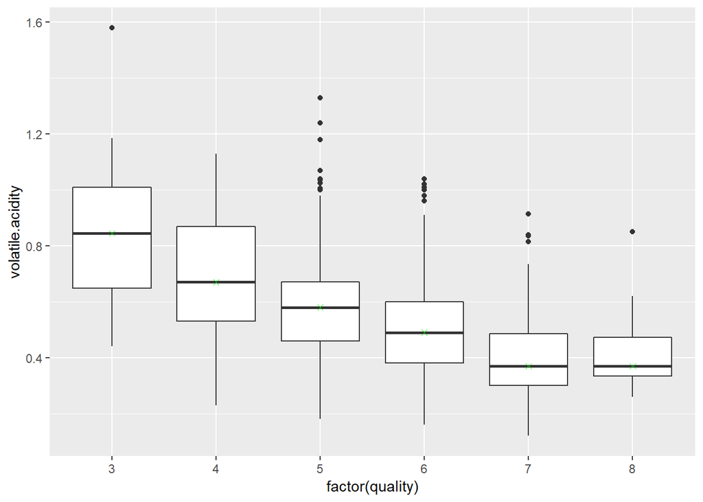

```
## wine_quality_reds$quality: 3
##    Min. 1st Qu.  Median    Mean 3rd Qu.    Max.
##  0.4400  0.6475  0.8450  0.8845  1.0100  1.5800
## --------------------------------------------------------
## wine_quality_reds$quality: 4
##    Min. 1st Qu.  Median    Mean 3rd Qu.    Max.
##   0.230   0.530   0.670   0.694   0.870   1.130
## --------------------------------------------------------
## wine_quality_reds$quality: 5
##    Min. 1st Qu.  Median    Mean 3rd Qu.    Max.
##   0.180   0.460   0.580   0.577   0.670   1.330
## --------------------------------------------------------
## wine_quality_reds$quality: 6
##    Min. 1st Qu.  Median    Mean 3rd Qu.    Max.
##  0.1600  0.3800  0.4900  0.4975  0.6000  1.0400
## --------------------------------------------------------
## wine_quality_reds$quality: 7
##    Min. 1st Qu.  Median    Mean 3rd Qu.    Max.
##  0.1200  0.3000  0.3700  0.4039  0.4850  0.9150
## --------------------------------------------------------
## wine_quality_reds$quality: 8
##    Min. 1st Qu.  Median    Mean 3rd Qu.    Max.
##  0.2600  0.3350  0.3700  0.4233  0.4725  0.8500
```

可以，从上图中发现，红酒的品质越高，所含有的乙酸含量更低。

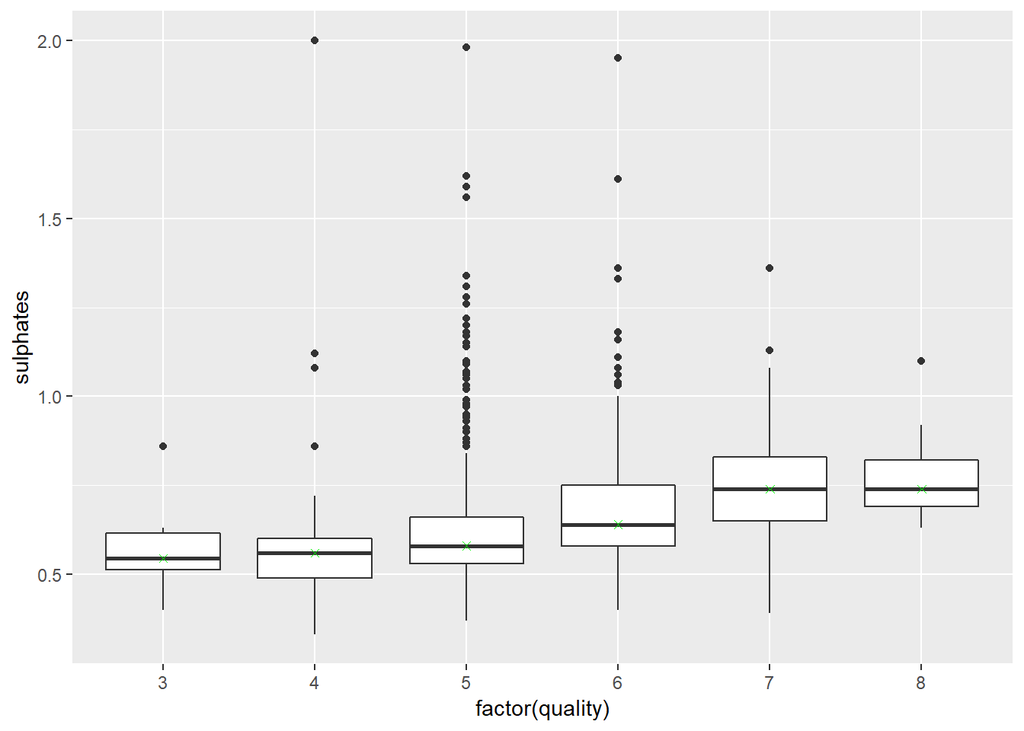

从图中，我们可以观察到红酒的质量跟硫酸钾的浓度呈一定的正相关关系，当不是很强烈。

[figure not shown]

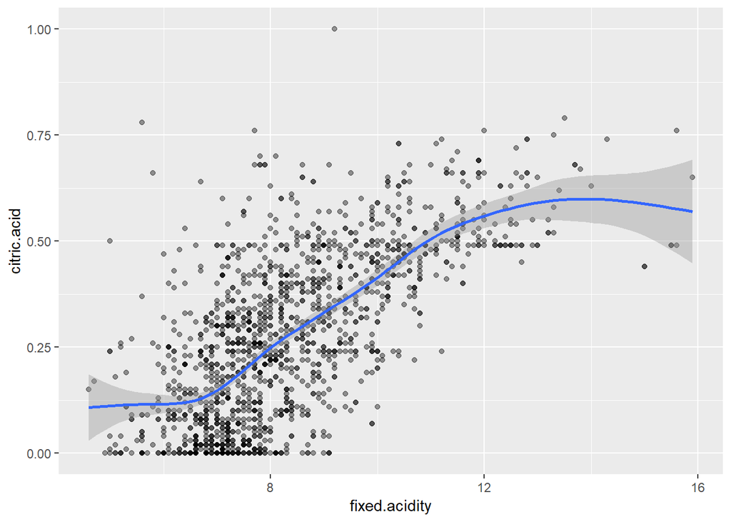

```
##
##  Pearson's product-moment correlation
##
## data:  wine_quality_reds$fixed.acidity and wine_quality_reds$citric.acid
## t = 36.234, df = 1597, p-value < 2.2e-16
## alternative hypothesis: true correlation is not equal to 0
## 95 percent confidence interval:
##  0.6438839 0.6977493
## sample estimates:
##       cor
## 0.6717034
```

```r
# 构造双变量之间的的关系函数
double_plot_var <-  function(varname1, varname2) {
  return(
    ggplot(data = wine_quality_reds, aes_string(x = varname1 , y = varname2))
    +geom_point(alpha = 0.4) + geom_smooth() )
}
```

可以观察到,fixed acidity 与 citric acid存在正相关关系，达到0.67

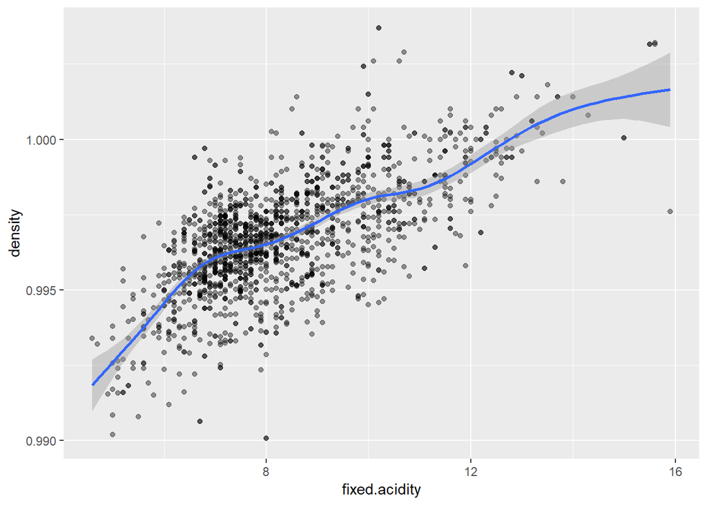

```
##
##  Pearson's product-moment correlation
##
## data:  wine_quality_reds$fixed.acidity and wine_quality_reds$density
## t = 35.877, df = 1597, p-value < 2.2e-16
## alternative hypothesis: true correlation is not equal to 0
## 95 percent confidence interval:
##  0.6399847 0.6943302
## sample estimates:
##       cor
## 0.6680473
```

从上图可以观察到，fixed acidity 和densitt呈现正相关关系，达到0.67

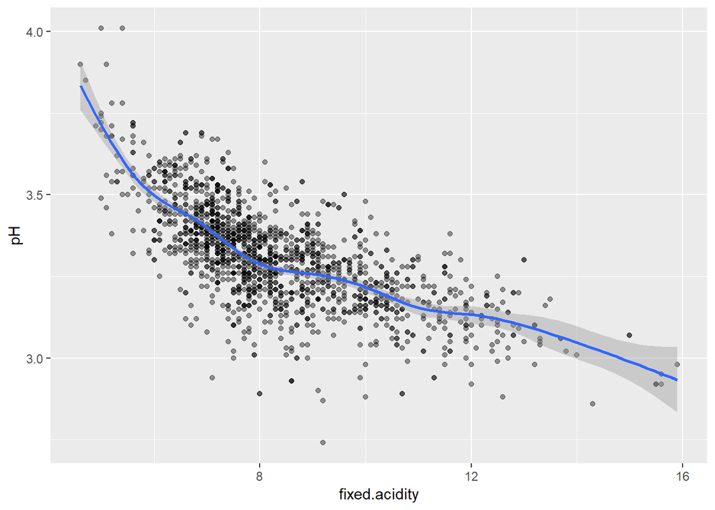

```
##
##  Pearson's product-moment correlation
##
## data:  wine_quality_reds$fixed.acidity and wine_quality_reds$pH
## t = -37.366, df = 1597, p-value < 2.2e-16
## alternative hypothesis: true correlation is not equal to 0
## 95 percent confidence interval:
##  -0.7082857 -0.6559174
## sample estimates:
##        cor
## -0.6829782
```

可以观察到，fixed acidity与PH呈现反相关关系，达到0.68。

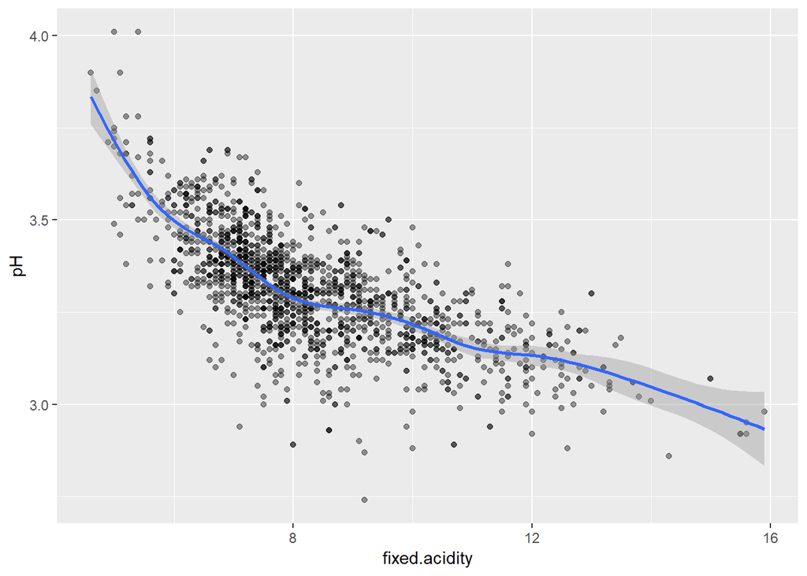

```
##
##  Pearson's product-moment correlation
##
## data:  wine_quality_reds$fixed.acidity and wine_quality_reds$pH
## t = -37.366, df = 1597, p-value < 2.2e-16
## alternative hypothesis: true correlation is not equal to 0
## 95 percent confidence interval:
##  -0.7082857 -0.6559174
## sample estimates:
##        cor
## -0.6829782
```

fixed acidity与PH呈现反相关关系，达到0.68。

[figure not shown]

[output not shown]

volatile acidity 和critric acid呈现反相关关系，达到0.55。

# 双变量分析

### 探讨你在这部分探究中观察到的一些关系。这些感兴趣的特性与数据集内其他特性有什么区别？

我们先对我们目标变量红酒质量quality来看， quality与alochol存在较强的的正相关性，相关系数为0.48； quality与sulphates存在较弱的正相关关系，仅为0.25； qulity与citric acid存在较弱的正相关关系，仅为0.23； quality与volatile acidity存在较弱的负相关关系，仅为0.39；

fixed acidity 与 citric acid存在正相关关系，达到0.67。 fixed acidity 和density呈现正相关关系，达到0.67。 fixed acidity与PH呈现反相关关系，达到0.68。 volatile acidity 和critric acid呈现反相关关系，达到0.55。其他变量间呈现的是弱相关关系。

### 你是否观察到主要特性与其他特性之间的有趣关系？

红酒中残糖量竟然对红酒的质量没有影响，或者说是没有表现出相关关系。

### 你发现最强的关系是什么？

# 多变量绘图选择

由上面的推论中，我们发现alcohol，volatile.acidity，sulphates，citric.acid对红酒质量quality影响比较大， 我们可以探究他们直接的关系。

## quality & alcohol & volatile.acidity

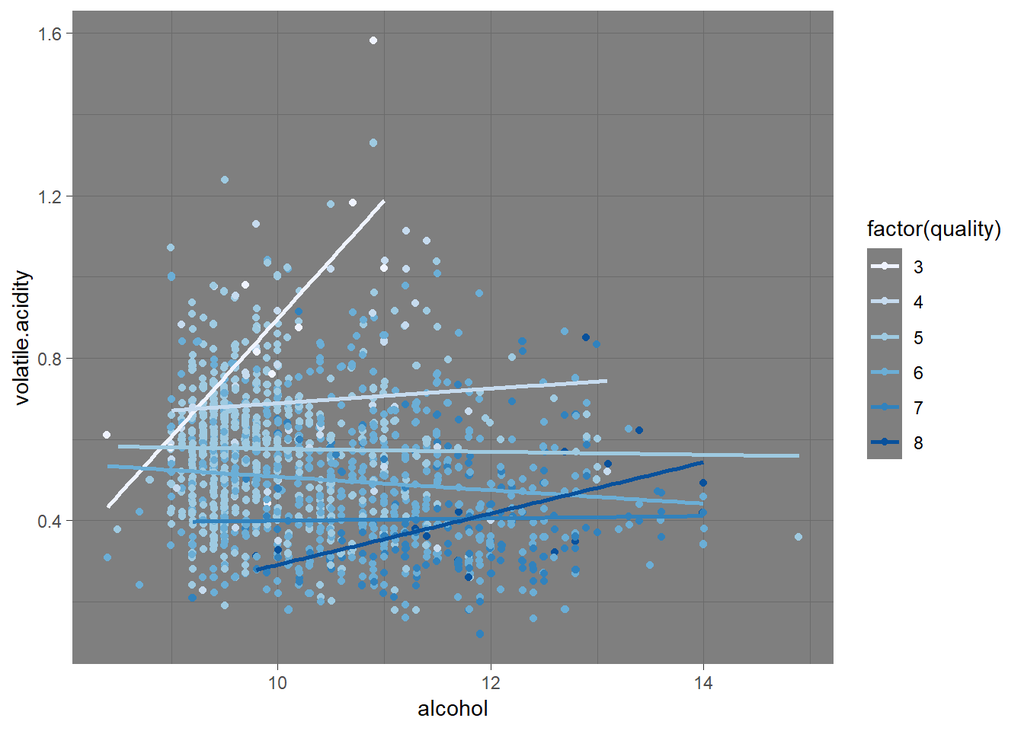

我们可以观察到比较深颜色的点都在右下方，说明红酒质量随着酒精浓度提升，和乙酸浓度地下降而提高。

## quality & alcohol & sulphates

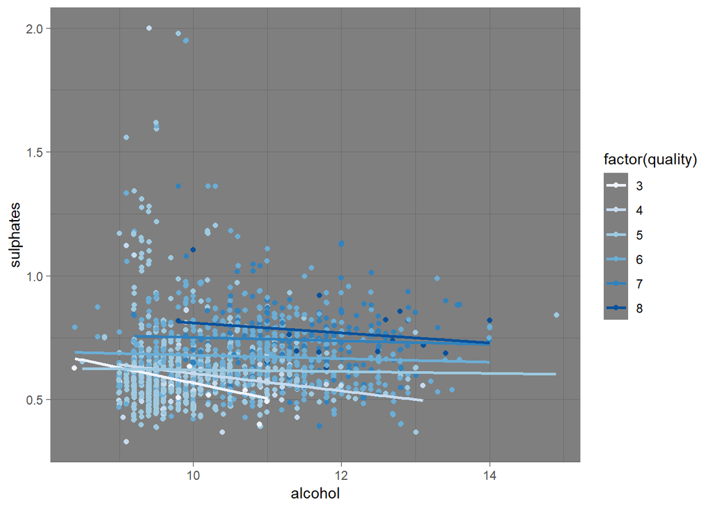

我们可以观察到比较深颜色的点都由左下往右上方蔓延，说明红酒质量随着酒精浓度提升，和硫酸钾浓度地上升而提高。

## quality & alcohol & citric.acid

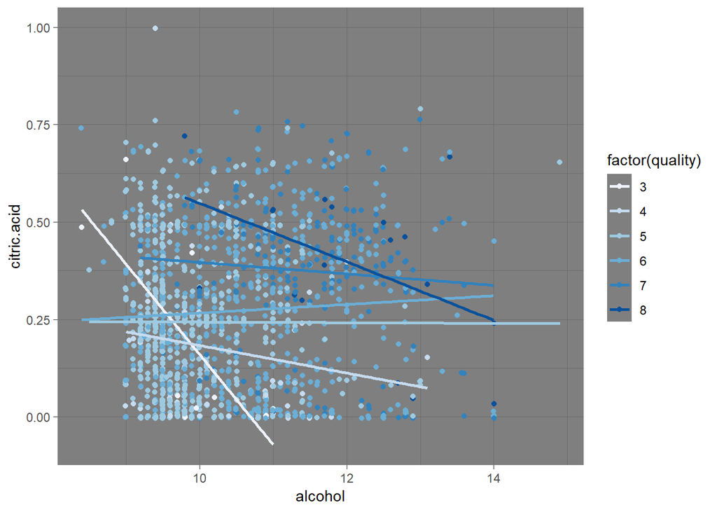

## quality & volatile.acidity & sulphates

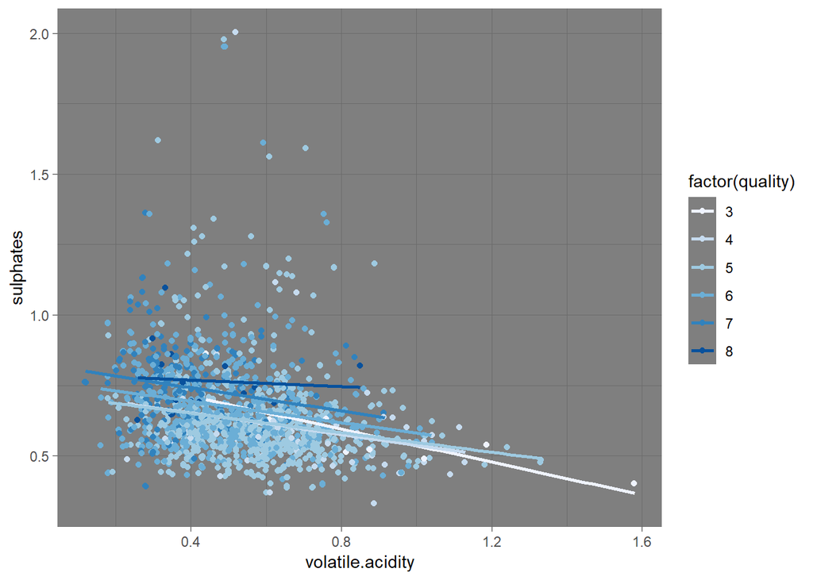

我们可以观察到比较深颜色的点都由右下往左上方蔓延，说明红酒质量随着乙酸浓度下降，和硫酸钾浓度地上升而提高。

## quality & volatile.acidity & citric.acid

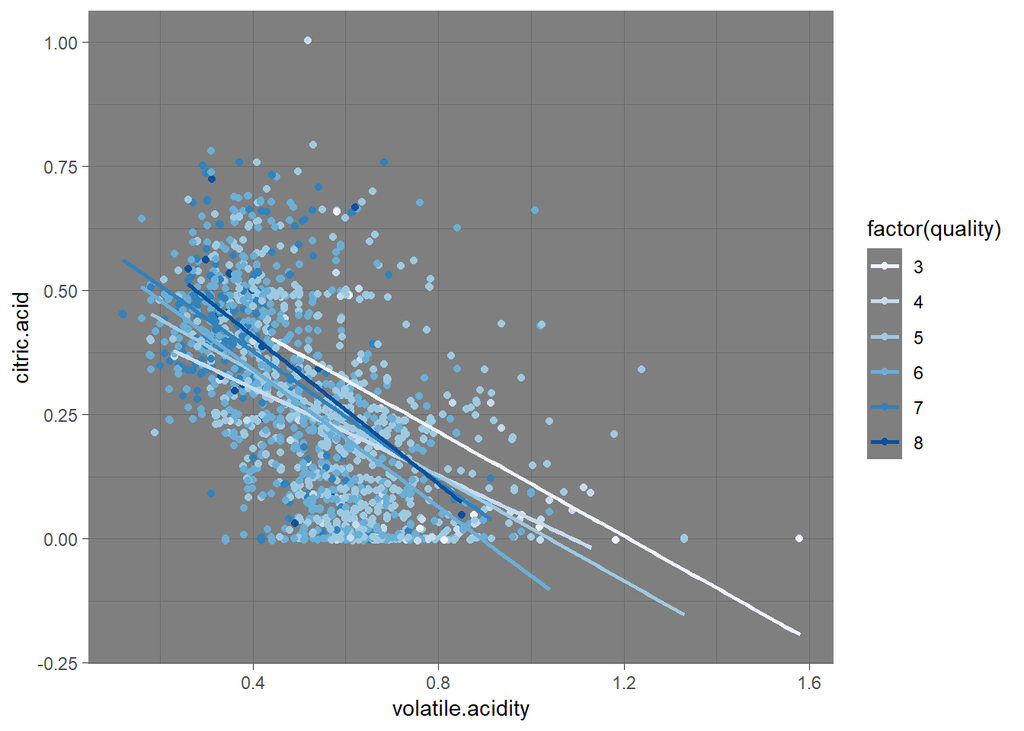

我们可以观察到比较深颜色的点都由右下往左上方蔓延，说明红酒质量随着乙酸浓度下降，和柠檬酸浓度地上升而提高。

## quality & sulphates & citric.acid

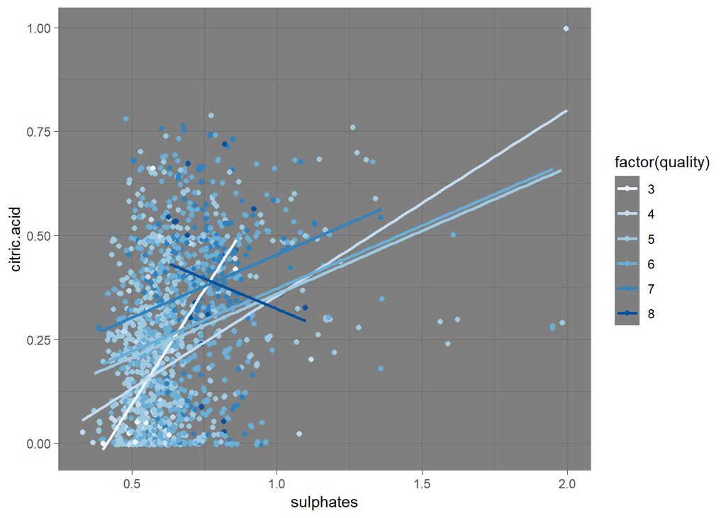

我们可以观察到比较深颜色的点都由左下往右上方蔓延，说明红酒质量随着硫酸钾浓度提升，和柠檬酸浓度地上升而提高。

# 多变量分析

### 探讨你在这部分探究中观察到的一些关系。通过观察感兴趣的特性，是否存在相互促进的特性？

从以上来看，我们可以发现： 红酒质量随着酒精浓度提升，和乙酸浓度地下降而提高。 红酒质量随着酒精浓度提升，和硫酸钾浓度地上升而提高。 红酒质量随着酒精浓度提升，和柠檬酸浓度地上升而提高。 红酒质量随着乙酸浓度下降，和硫酸钾浓度地上升而提高。 红酒质量随着乙酸浓度下降，和柠檬酸浓度地上升而提高 红酒质量随着硫酸钾浓度提升，和柠檬酸浓度地上升而提高。 综合来说就是，在一定范围内，红酒的质量随乙酸浓度下降， 酒精浓度提升，硫酸钾浓度地上升，柠檬酸浓度地上升而上升。

### 这些特性之间是否存在有趣或惊人的联系呢？

与quality呈正相关的变量，两两之间也是呈正相关关系，其他变量都与与volatile.acidity都呈负相关关系。

### 选项：你是否创建过数据集的任何模型？讨论你模型的优缺点。

——否

# 定稿图与总结

### 绘图一

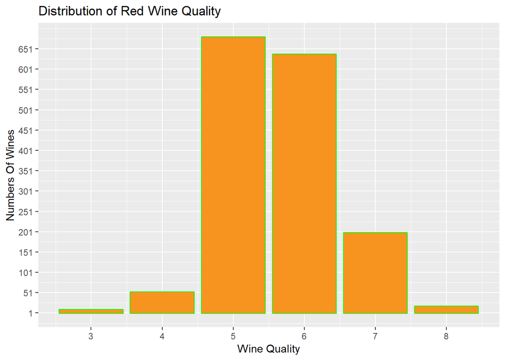

### 绘图二

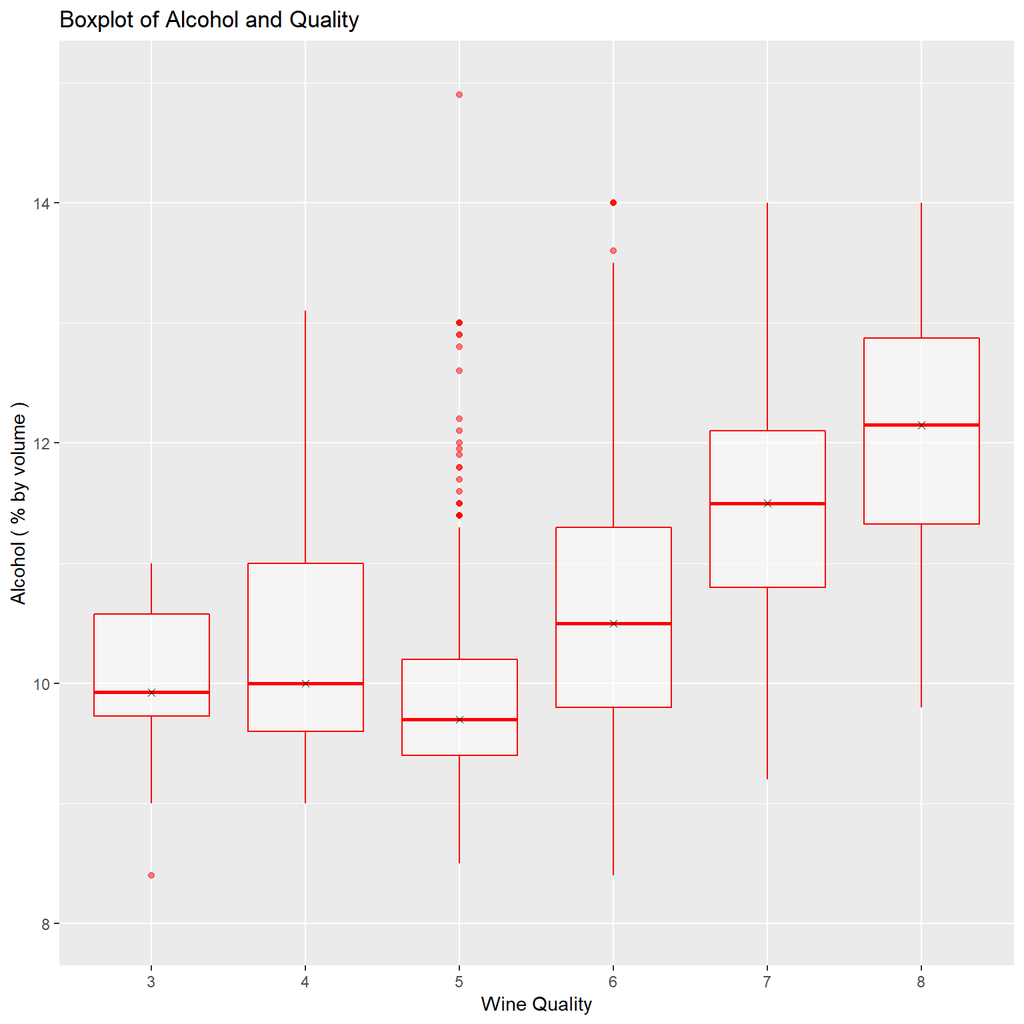

### 描述二

我们选择与quality相关性最大的alcohol特性，由于quality值为3，4还有8的数量很少， 因此总体上alcohol的值越大，quality值越大，两者呈正相关。而且我们还可以看出alcohol的值集中在9-11度左右。

### 绘图三

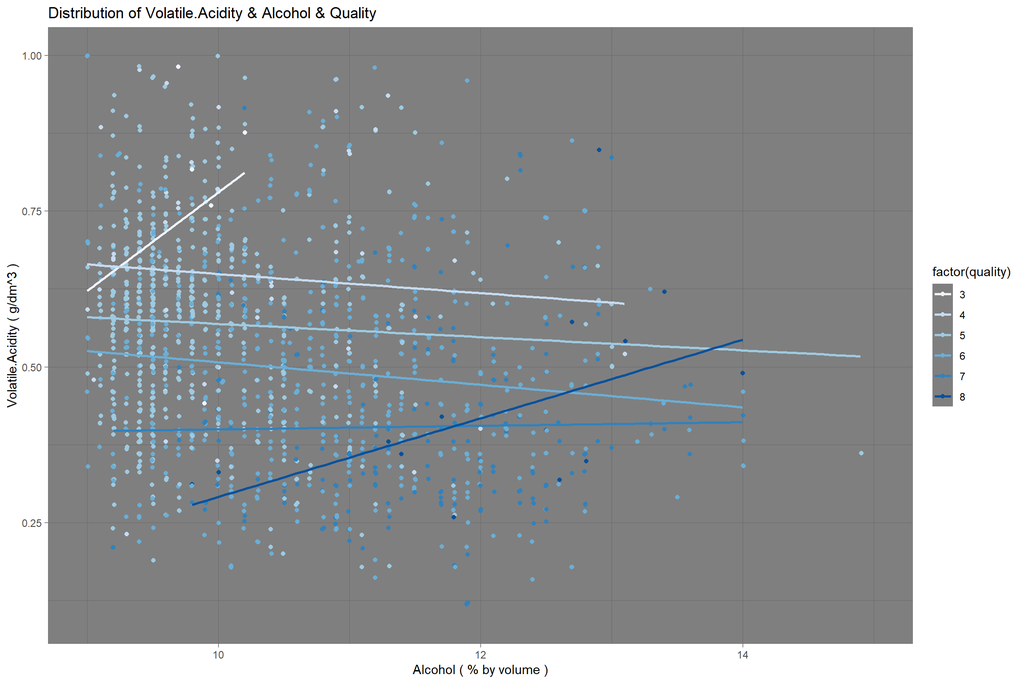

### 描述三

上图可以反映出alcohol, volatile.acidity, quality之间的关系， 随着alcohol的值增大，fator值大的点数在增加； 在volatile.acidity值大的区域内，factor值小的点数比较多。 quality与alcohol呈正相关性，与volatile.acidity呈负相关性。 总结来说，alcohol值越大， volatile.acidity值越小，红酒的品质越高。 ——

# 反思

## 难点：

1. 数据刚拿到手时不知道从何分析，再度回去重温了一下课程，发现课程是从单变量，双变量，多变量逐渐递进的，因此我就模仿了课程来完成此项目。
2. 在审阅之前，存在大量冗余代码，经过审阅提示之后，自定义函数的方式来减少代码重复，一下子简化了步骤。
3. 在绘制图形的时候，需要调图像尺寸，调节横纵轴标签，比较需要耐心。
4. 每天刚到一两点来完成这个项目，宝宝，好心累呐。

## 发现：

从一团乱麻的数据，发现了变量之间的相关性，发现了影响红酒品质的几个重要变量，好激动！！！ 再从这几个相关变量中发现了一个数据规律，alcohol值越大， volatile.acidity值越小，红酒的品质越高。 这就是革命胜利的一大步呐！！！从无到有，从混沌到有序，我似一个探索真理的学者，匍匐在数据里面找寻答案。

## 改进：

在未来，还是得不断学习数据分析技巧，增强可视化能力。 如果可以，我还是希望能利用R来构建数学模型，预测红酒品质的。